# Getting Started with VibeCluster

VibeCluster Authors

2026-04-04

## What is VibeCluster?

**VibeCluster** answers a simple question: *“Given the way a song sounds, what mood does it create — and what other songs will make me feel the same way?”*

It uses three statistical methods from course:

| Method | Role |
| --- | --- |
| **K-Means Clustering** | Groups songs into *k* mood clusters |
| **PCA** | Projects 6-D features to 2-D for the Mood Map |
| **kNN** | Finds the *n* songs closest to your mood profile |

## Step 1 — Load the Dataset

```r
library(VibeCluster)

songs <- load_songs()
print(songs)
```

```
#> === VibeCluster Song Dataset ===
#> Songs   : 364
#> Features: energy, valence, danceability, tempo_norm, acousticness, loudness_norm
#> Moods   : Happy=66  Melancholic=63  Calm=62  Energetic=60  Romantic=58  Angry=55
#> Scaled  : FALSE
```

The built-in dataset has **364 songs** across 6 mood archetypes with 6 audio features each (energy, valence, danceability, tempo, acousticness, loudness).

```r
df <- mood_summary(songs, k_range = 2:8)
```

```
#> Running k = 2
#> Running k = 3
#> Running k = 4
#> Running k = 5
#> Running k = 6
#> Running k = 7
#> Running k = 8
```

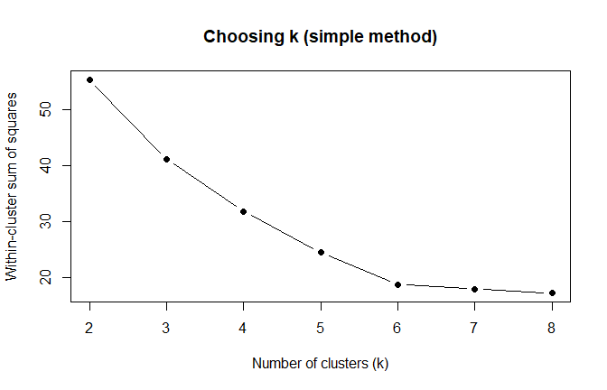

```r
df
```

```
#>   k within_ss
#> 1 2  55.40334
#> 2 3  41.15297
#> 3 4  31.83130
#> 4 5  24.48047
#> 5 6  18.73876
#> 6 7  17.95142
#> 7 8  17.23201
```

## Step 3 — Cluster into Mood Groups

```r
result <- mood_cluster(songs, k = 6)
print(result)
```

```
#> === VibeCluster Result ===
#> Songs    : 364
#> k        : 6
#> Within SS: 18.7384
#>
#>   Cluster        Mood Songs Percent
#> 1       1       Happy    66   18.1%
#> 2       2        Calm    63   17.3%
#> 3       3       Angry    55   15.1%
#> 4       4   Energetic    60   16.5%
#> 5       5    Romantic    58   15.9%
#> 6       6 Melancholic    62     17%
#>
#> Features: energy, valence, danceability, tempo_norm, acousticness, loudness_norm
```

Each song now has a `mood` column with its cluster label. Cluster centres are automatically matched to mood names by nearest-archetype distance.

```r
head(result$songs[, c("title", "artist", "mood", "energy", "valence")])
```

```
#> === VibeCluster Song Dataset ===
#> Songs   : 6
#> Features: energy, valence, danceability, tempo_norm, acousticness, loudness_norm
#> Scaled  : FALSE
```

## Step 4 — The Mood Map (PCA)

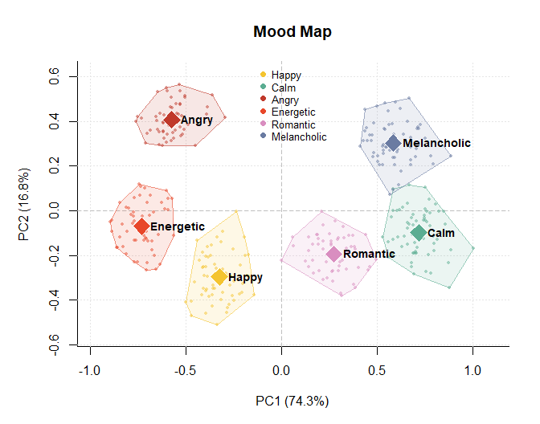

```r
plot_mood_map(result)
```

Each dot is a song; diamonds mark cluster centroids; convex hulls outline each mood’s territory. PC1 captures roughly the *energy–acousticness* axis and PC2 captures *valence*.

## Step 5 — Mood Palette + Feature Profiles

```r
pal <- get_mood_palette(result)
```

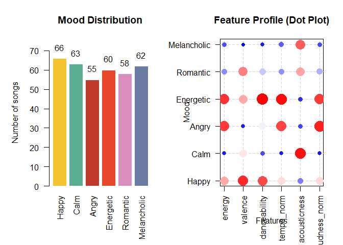

```r
print(pal[, c("mood", "count", "proportion")])
```

```
#>           mood    count proportion
#> 1        Happy 2.322300 0.03264644
#> 2         Calm 1.110938 0.01561736
#> 3        Angry 2.776280 0.03902841
#> 4    Energetic 2.795095 0.03929290
#> 5     Romantic 1.543840 0.02170301
#> 6  Melancholic 1.307356 0.01837856
#> 7        Happy 2.824196 0.03970200
#> 8         Calm 2.089797 0.02937796
#> 9        Angry 1.118370 0.01572183
#> 10   Energetic 2.330281 0.03275863
#> 11    Romantic 2.493165 0.03504843
#> 12 Melancholic 1.000000 0.01405781
#> 13       Happy 2.704065 0.03801322
#> 14        Calm 1.309406 0.01840738
```

[output cut: 22 more lines]

The heatmap on the right shows each cluster’s mean feature profile — you can see Energetic songs are high energy + high tempo + high loudness, while Calm songs are high acousticness + low tempo.

## Step 6 — Personalised Recommendations (kNN)

Define your mood profile as a 6-element feature vector, then ask for the closest songs:

```r
# High-energy, dark mood — Angry/Energetic profile
my_profile <- c(energy        = 0.90,
                valence       = 0.15,
                danceability  = 0.55,
                tempo_norm    = 0.85,
                acousticness  = 0.05,
                loudness_norm = 0.92)

recs <- recommend_songs(result, profile = my_profile, n = 8)
```

```
#> === VibeCluster Recommendations ===
#>   Query mood (nearest centroid): Angry
#>   Searched                     : All clusters
#>   Top 8 recommendations:
#>
#>  rank                   title              artist  mood distance
#>     1                Kill You              Eminem Angry   0.0856
#>     2     Points of Authority         Linkin Park Angry   0.0950
#>     3          Wait and Bleed            Slipknot Angry   0.1621
#>     4             Break Stuff         Limp Bizkit Angry   0.1644
#>     5 Vulgar Display of Power             Pantera Angry   0.1666
#>     6      War Inside My Head Suicidal Tendencies Angry   0.1674
#>     7               This Love             Pantera Angry   0.1683
#>     8       Land of Confusion           Disturbed Angry   0.1715
```

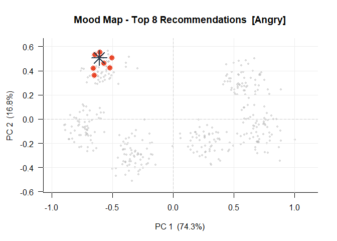

```r
# Acoustic, gentle profile
calm_profile <- c(energy        = 0.18,
                  valence       = 0.65,
                  danceability  = 0.35,
                  tempo_norm    = 0.20,
                  acousticness  = 0.88,
                  loudness_norm = 0.18)

recs_calm <- recommend_songs(result, profile = calm_profile, n = 8,
                             from_mood = "Calm")
```

```
#> === VibeCluster Recommendations ===
#>   Query mood (nearest centroid): Calm
#>   Searched                     : Calm
#>   Top 8 recommendations:
#>
#>  rank                    title           artist mood distance
#>     1                    Angel     Jimi Hendrix Calm   0.1604
#>     2                Landslide    Fleetwood Mac Calm   0.1740
#>     3               Experience Ludovico Einaudi Calm   0.1796
#>     4        Those Sweet Words      Norah Jones Calm   0.1796
#>     5              Us and Them       Pink Floyd Calm   0.1962
#>     6                Blackbird      The Beatles Calm   0.1971
#>     7 The Great Gig in the Sky       Pink Floyd Calm   0.1993
#>     8                Into Dust       Mazzy Star Calm   0.2026
```

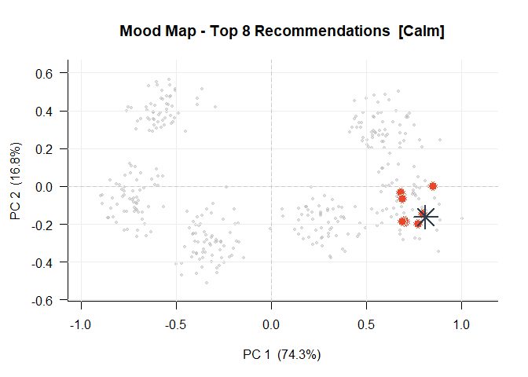

The Mood Map highlights your profile (★) and the recommended songs (●) so you can see where they sit in the mood landscape.

## Bringing Your Own Data

Export tracks from the Spotify Web API (or use the `spotifyr` package), normalise the features, and pass the CSV to `load_songs()`:

```r
my_songs <- load_songs("my_spotify_tracks.csv")
result   <- mood_cluster(my_songs, k = 6)
```

Your CSV only needs the six feature columns; `title` and `artist` are optional but will appear in recommendation output.

## Function Reference

[output not shown]